# Australian Shark Attack Data Presentation

## Project Concept: Australian Shark Attack Data.

In this project, I will be exploring data outlining shark attacks in Australia from 1791 until the present day. I want to know if there is a correlation between fatal and provoked attacks, and what types of sharks are most likely to participate in provoked vs unprovoked attacks.

## Questions explored in this presentation

1. Is there a correlation between if an attack is provoked and if the person was killed?
2. What kind of shark is most likely to participate in a provoked vs an unprovoked attack?

[figure not shown]

Tiger Shark. Credit: skynews-tiger-shark-generic_4172004.jpg

## Question 1 Graph: Is there a correlation between provoked and fatal attacks?

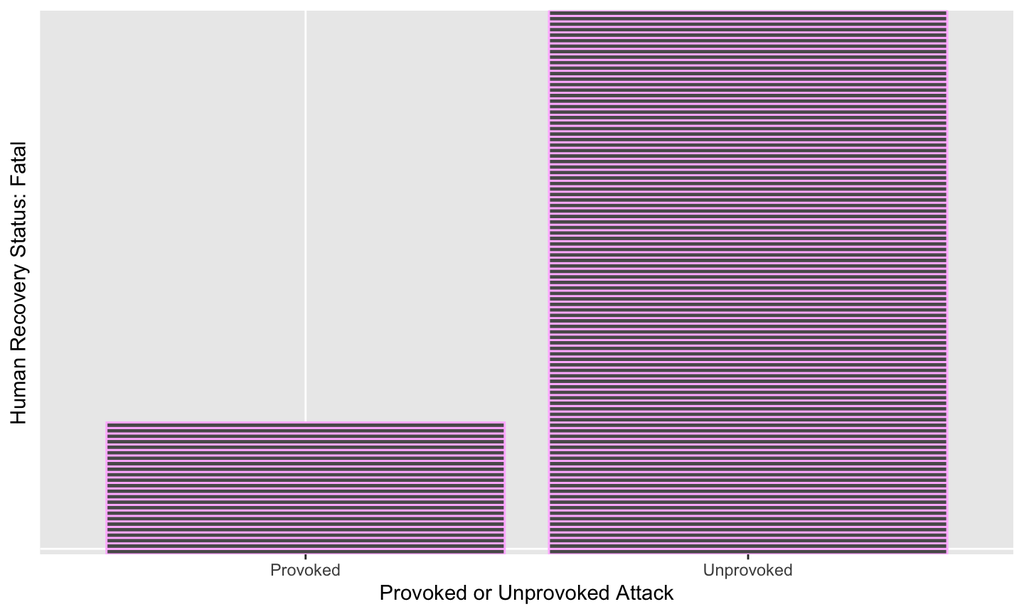

## Question 1 Conclusion: Is there a correlation between provoked and fatal attacks?

*Conclusion:*

- More fatal unprovoked attacks, why?
- Australian data
- Sharks may mistake people on surfboards for seals

[figure not shown]

Human vs Seal. Credit: https://www.dailymail.co.uk/

## Question 2 Graph: What kind of shark is most likely to participate in a provoked vs an unprovoked attack?

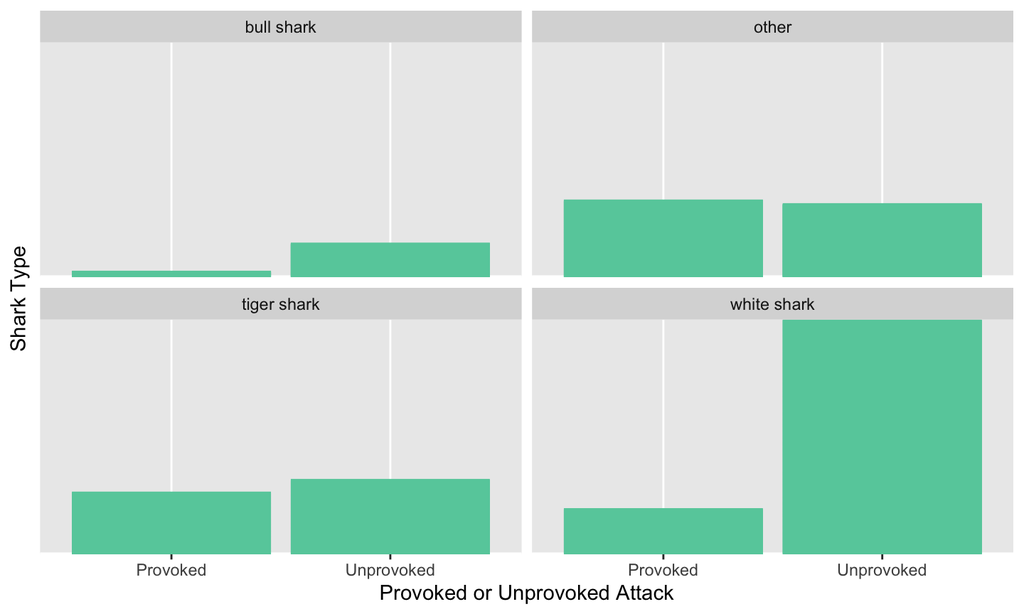

## Question 2 Conclusion: What kind of shark is most likely to participate in a provoked vs an unprovoked attack?

*Conclusion:*

- Great White sharks most likely to attack unprovoked
- Could be related to seal diet
- Bull sharks known as aggressive, but eat smaller prey

[figure not shown]

Great White Shark. Credit: https://theconversation.com/

## Citation

Bradshaw, Corey. @cjabradshaw. “Australian Shark Incident Database” https://github.com/cjabradshaw/AustralianSharkIncidentDatabase September 19th, 2021 - Present.